# **1. What is RASA?**

RASA is a task oriented dialog system. It is Machine Learning/Rule based framework to build chatbots.

RASA is a framework that makes it easier to build custom assitants & chatbots.

# **2. What features do RASA take from the history of NLP?**

RASA combines different aspects from the history of NLP.

• RASA defines rules on what the assistant is going to say next.

• For extracting dates and numbers, RASA uses regular expressions which is rule based.

• RASA uses neural methods trying to understand what the user is trying to communicate.

To understand how NLP has evolved over time, look at the following diagram:

```python
from google.colab import files
from IPython.display import Image
```

```python
uploaded = files.upload()
```

Upload widget is only available when the cell has been executed in the current browser session. Please rerun this cell to enable.

```
Saving Rasa_history.png to Rasa_history.png
```

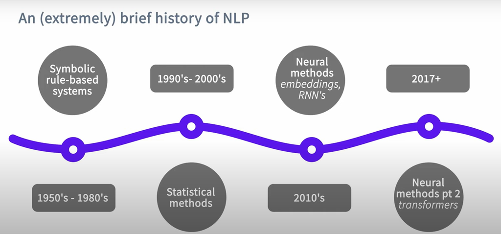

```python
Image('Rasa_history.png', width = 800)
```

# **3. What are the different approaches used in RASA?**

There are 2 approaches used in a RASA assistant:

• State machine

• Neural methods

While the steps used are:

• NLU (Natural Language Understanding)

• Dialog policy

# **4. What is NLU?**

**NLU** aka **Natural Language Understanding** is where we give raw text in and extract machine readable information out of it. It is the process step where we try to understand the text.

As mentioned earler there are 2 approaches used here:

- State machine (Rule based)
- Neural methods

Let us understand each one of them

**1.** **Rule based (State machine approach)**

- Example of a rule-based system is a regular expression (Regex) that finds and extracts email addresses.
- One does not need much data for these approaches.
- They run very fast.
- However, they are not good at handling things that they haven't seen before.

**2.** **Neural method**

- Example of neural method would be a transformer based model (e.g. DIET) that sorts text into intents based on the example it has been provided.
- Requires training example (in general). The more the better.
- Unlike rule based systems, they are very good at handling things they haven't seen before. It makes informed guesses.

A RASA assistant may use both: E.g To track spam email messages – regular expressions (REGEX). Different ways that someone can order a pizza – neural method.

# **5. What is Dialog policy?**

Once we have given the information, we have to consider what to do next. Dialog policy is basically understanding what to do next.

As mentioned earlier there are 2 approaches used here as well:

- State machine (Rule based)
- Neural methods

Let us understand each one of them,

**1.** **Rule based (State machine approach)**

- It basically contains a big dialog tree with all the paths a possible conversation can take.
- It is a traditional approach to dialog and can work well in some cases.
- They run very fast.
- However, they are not good at handling digressions and are bit of a pain to to extend/maintain. Digression is an action of moving away from a main subject while one is writing/talking about something else.

**2.** **Neural method**

- Example of neural method would be a transformer based model (e.g. TED) that picks the next turn based on the conversation so far and all the conversation it's been trained on.
- Requires training example (in general). The more the better.
- Unlike rule based systems, this approach helps user to have natural conversations, even if the user says things in a different order every time.

At RASA, it is recommended to use both systems in a tandem manner for a dialog policy.

# **6. How to make conversations work and improve over time. (Conversation-driven development)?**

One can improve the conversations over time by manually reviewig and annotating conversations.This process is called 'Conversation Driven Development (CDD).'

This can be done by manually correcting any errors that assistant may have done during conversations, then add it to training data, retrain & redepoly.

A RASA conversational AI system isn't static, it changes and adapts over time.

# **7. What are the steps to make a RASA assitant?**

To create a RASA assistant follow the steps mentioned below in your anaconda command prompt:

1. Create a folder - mkdir chatbot
2. Go to the folder - cd chatbot
3. create an environment - conda create -n chatbot python==3.18.10 (chatbot is the name of the env)
4. Activate the environment - conda activate chatbot
5. clear the cache - python -m pip cache purge
6. upgrade pip - python -m pip install -U pip
7. Installing rasa - pip install rasa==3.0.2
8. Installing websockets - pip install websockets==10.0
9. Installing protobuf- pip install protobuf==3.20
10. Initialise rasa for a new project- rasa init **Specify the path in current directory as - . (type dot)
11. Train the model - rasa Train train with fixed name - rasa train --fixed-model-name model.tar.gz
12. Use the chatbot - rasa shell
13. Evaluate the model - rasa shell nlu

**Note: Try creating an environment on python = 3.8 if there's any issue creating on 3.18.10. A deprecated version 3.8 is more suitable for RASA.**

# **8. How does a RASA assistant looks like?**

To chat with a RASA assistant type the command 'rasa shell'. The conversation flow of RASA is shown below.

```python
uploaded = files.upload()
```

Upload widget is only available when the cell has been executed in the current browser session. Please rerun this cell to enable.

```
Saving Rasa_chatbot.png to Rasa_chatbot.png
```

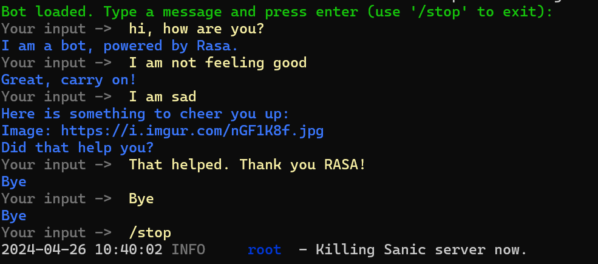

```python
Image('Rasa_chatbot.png', width = 800)
```

# **9. Understanding the structure of RASA assistant**

Once you have initialised the assistant in RASA using (RASA init) the assitant will create a code in the directory where you have loaded the project. Let us look what all files do a typical RASA assistant has.

```python
uploaded = files.upload()
```

Upload widget is only available when the cell has been executed in the current browser session. Please rerun this cell to enable.

```
Saving Rasa_backend_1.png to Rasa_backend_1.png
```

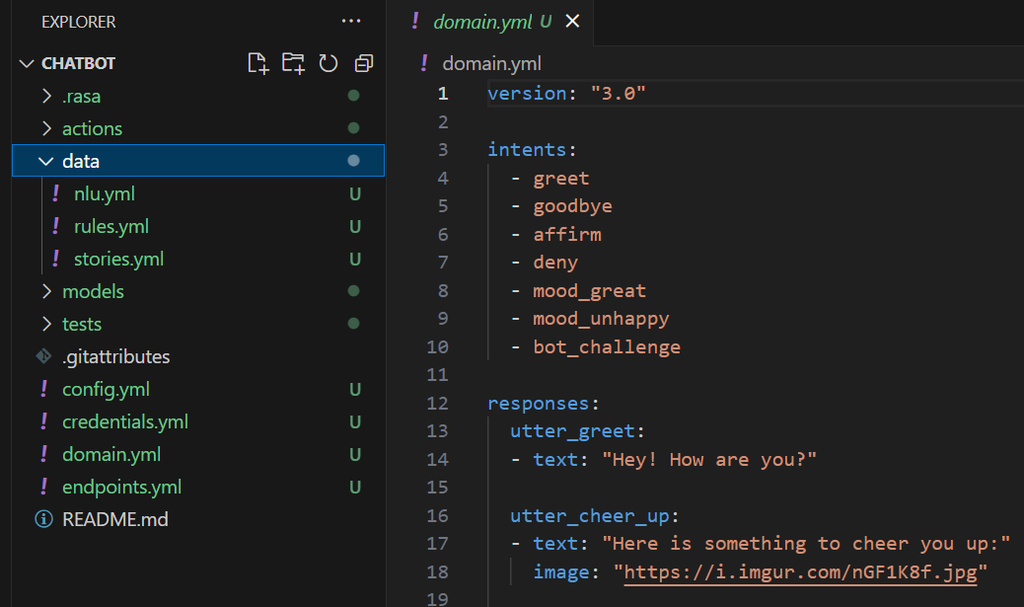

```python
Image('Rasa_backend_1.png', width = 800)
```

RASA assistant comprises of domain, data (nlu, rules, stories), config , credentials and endpoint files. Out of which for faq chatbot changes needs to be done only in 3 files

1. NLU
2. Domain
3. Stories

Let us understand each file, one by one.

# **10. What is Domain file?**

Domain file is the most important file that contains intent of the user, responses of the assistant & session configuration.

Intent is the intention with which the user is communicating. To give an example, 'Hi', 'hey', 'How are you?' comes under the intent 'greet' whereas 'See you again', 'Until next time', 'farewell' comes under the intent 'goodbye'.

Responses of the assistant are saved as utterances in the form of text. SO if a User says 'Hi, How are you?' then the response of the assitant 'I am good' is an utterance.

Session configuration comprises of specifications of one runtime of a session. 'session_expiration_time: 60' parameter sets the expiration time for a session. In this case, it's set to 60(e.g., seconds/ minutes/ hours). This means that after a certain period of inactivity, the session will expire and the user will need to start a new session.

'carry_over_slots_to_new_session: true' parameter determines whether the slots or data collected during the current session will be carried over to a new session when it starts. If set to true, any information collected from the user during the current session will be retained and accessible in the subsequent session. This can provide continuity in the conversation or workflow across multiple sessions.

```python
uploaded = files.upload()
```

Upload widget is only available when the cell has been executed in the current browser session. Please rerun this cell to enable.

```
Saving domain.png to domain.png
```

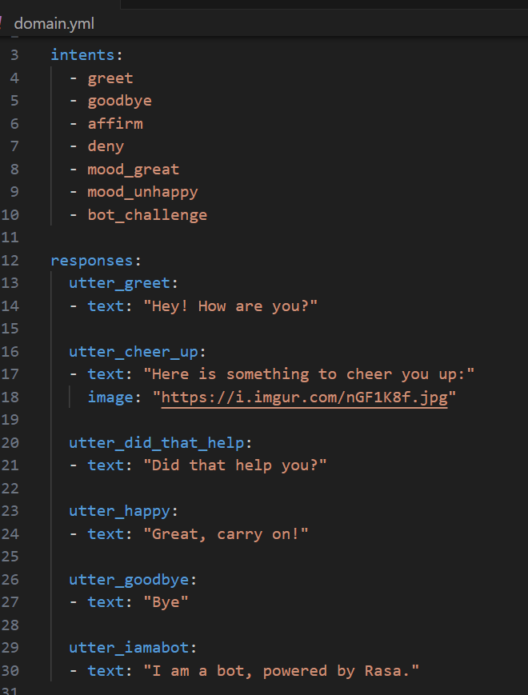

```python
Image('domain.png', width = 600)
```

# **11. What is config file?**

Config file contains the nlu pipeline. Pipleine consists of all the tasks NLU is lined up to execute.

```python
uploaded = files.upload()
```

Upload widget is only available when the cell has been executed in the current browser session. Please rerun this cell to enable.

```
Saving config.png to config.png
```

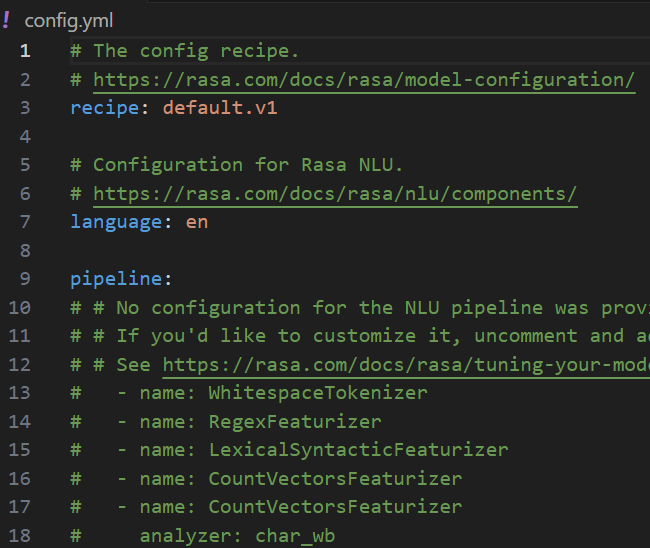

```python
Image('config.png', width = 600)
```

# **12. What are data files (nlu, rules, stories)?**

There are 3 data files:

nlu, rules & stories

**Nlu** file contains the intent with which user communicates and the examples of the way user communicates. For example, look at the image below:

```python
uploaded = files.upload()
```

Upload widget is only available when the cell has been executed in the current browser session. Please rerun this cell to enable.

```
Saving nlu.png to nlu.png
```

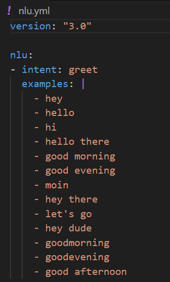

```python
Image('nlu.png', width = 300)
```

**Stories** show potential conversation flows. It consists of compilation of intents & actions. Actions comprises of utterances which are defined in domain file.

```python
uploaded = files.upload()
```

Upload widget is only available when the cell has been executed in the current browser session. Please rerun this cell to enable.

```
Saving stories.png to stories.png
```

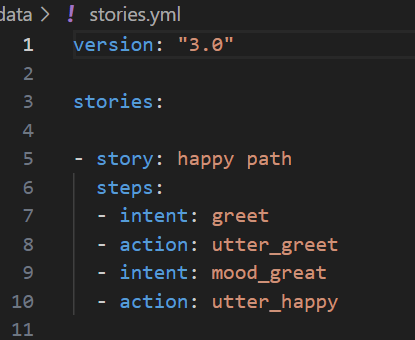

```python
Image('stories.png', width = 400)
```

**Rules** define conditional stories that will tell the assistant to do as the rule says if a particular intent & utterances are typed by the user.

```python
uploaded = files.upload()
```

Upload widget is only available when the cell has been executed in the current browser session. Please rerun this cell to enable.

```
Saving rules.png to rules.png
```

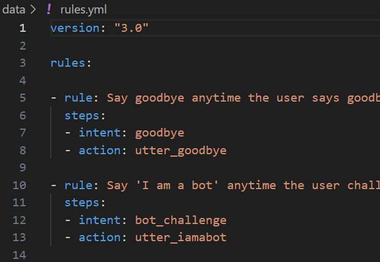

```python
Image('rules.png', width = 500)
```

# **13. Understanding the conversational flow**

To understand the conversational flow, type the command 'rasa shell nlu'.

```python
uploaded = files.upload()
```

Upload widget is only available when the cell has been executed in the current browser session. Please rerun this cell to enable.

```
Saving rasa_shell_nlu.png to rasa_shell_nlu.png
```

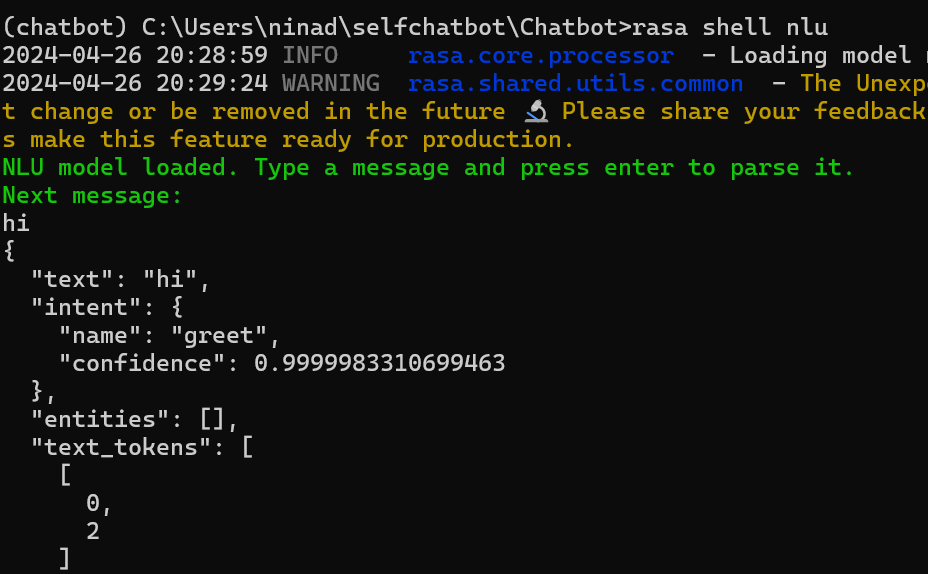

```python
Image('rasa_shell_nlu.png',width = 800)
```

When you said "hi", you initiated a greeting. In the context of natural language understanding, this is referred to as an "intent." An intent represents the goal or purpose behind a user's input. In this case, the intent is "greet," which indicates that you are initiating a conversation in a friendly manner.

Additionally, natural language understanding systems often look for "entities" within the user's input. Entities are specific pieces of information that the system can extract and use to better understand the user's request or query. In your message, there are no entities identified because "hi" doesn't contain any specific information other than the greeting itself.

Overall, when you said "hi," the system recognized it as a greeting with a high level of confidence (99.9998%).

In the case when the entered text has no intent/utterances/response, we get the message 'nlu_fallback' indicating no answer to the question avaliable.

# **14. List some important Command Line Interface (CLI) commands**

To get a list of all the command line interface (CLI) commands & their functions, type **rasa -h** in the shell window.

```python
uploaded = files.upload()
```

Upload widget is only available when the cell has been executed in the current browser session. Please rerun this cell to enable.

```
Saving rasa_help.png to rasa_help.png
```

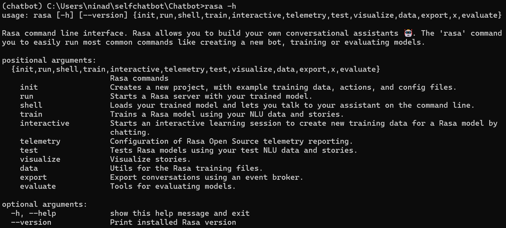

```python
Image('rasa_help.png')
```

Today we understood how to create a RASA assistant and interact with the chatbot. In addition to it, we understood how RASA is built and what are the important components of RASA. RASA is a framework and for aspiring data scientists rather an important one. So do keep a note of it.